# Fecundity-at-age

2023-01-28

# 1 SET-UP

```r
source('0.0_settings.R')
this.year <- 2022
```

# 2 Input data

## 2.1 Read

```r
# Pelletier data
pel <- read.csv('data/pelletier.csv')

# bio data
new <- FALSE
if(new){
    bio <- get.bio(species='maquereau',user=imlp.user,password=imlp.pass)
    save(bio,file=paste0('Rdata/bio_',Sys.Date(),'.Rdata'))
}else{
    df <- file.info(list.files("Rdata/", full.names = T,pattern="bio_"))
    load(rownames(df)[which.max(df$mtime)])
}
```

## 2.2 Transformations

```r
## Pelletier data
# add variables
pel$gsi <- with(pel,weight_gonads/weight*100)
pel$ageplus <- pmin(pel$age,10)

# melt dataframe
pelm <- pel[,c('id','fecundity','length','weight','age','weight_gonads','doy','gsi')]
pelm <- melt(pelm,id=c('id','fecundity'))

## bio data
# subset
bio$doy <- lubridate::yday(as.Date(paste(bio$year,bio$month,bio$day,sep='/')))
bio.faa <- bio[bio$matur==5 &
               bio$sex=='F' &
               bio$agef>0,
               c('year','month','matur','sex','wgonad','agef','weight','length.frozen','doy')]
bio.faa <- bio.faa[!is.na(bio.faa$agef) & !is.na(bio.faa$wgonad) & !is.na(bio.faa$weight),]
names(bio.faa)[c(6,8)] <- c('age','length')  # length kept to help identify potentially wrong ages

# transform/add
bio.faa$wgonad <- bio.faa$wgonad*1000 # same unit as pelletier (g)
bio.faa$weight <- bio.faa$weight*1000
bio.faa$gsi <- with(bio.faa,wgonad/weight*100)
bio.faa$ageplus <- pmin(bio.faa$age,10)
```

# 3 Pelletier data

## 3.1 Plots

### 3.1.1 relationships

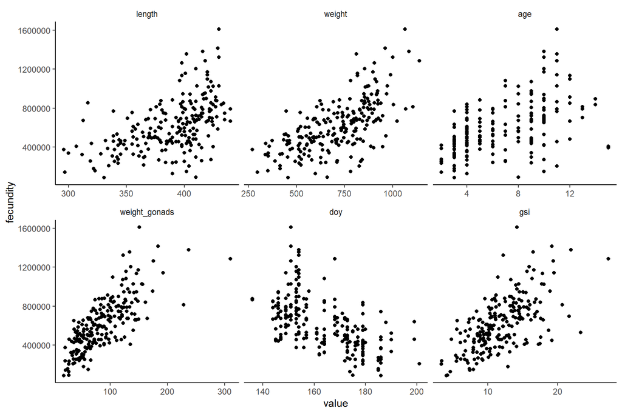

```r
ggplot(pelm,aes(y=fecundity,x=value))+
    geom_point()+
    facet_wrap(~variable,scale='free_x')
```

### 3.1.2 relationships (log)

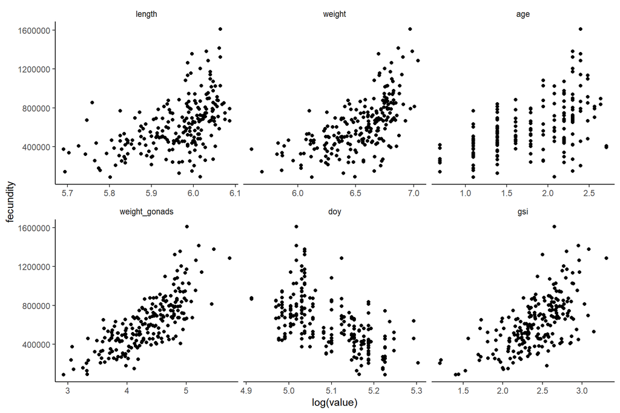

```r
ggplot(pelm,aes(y=fecundity,x=log(value)))+
    geom_point()+
    facet_wrap(~variable,scale='free_x')
```

### 3.1.3 pairs

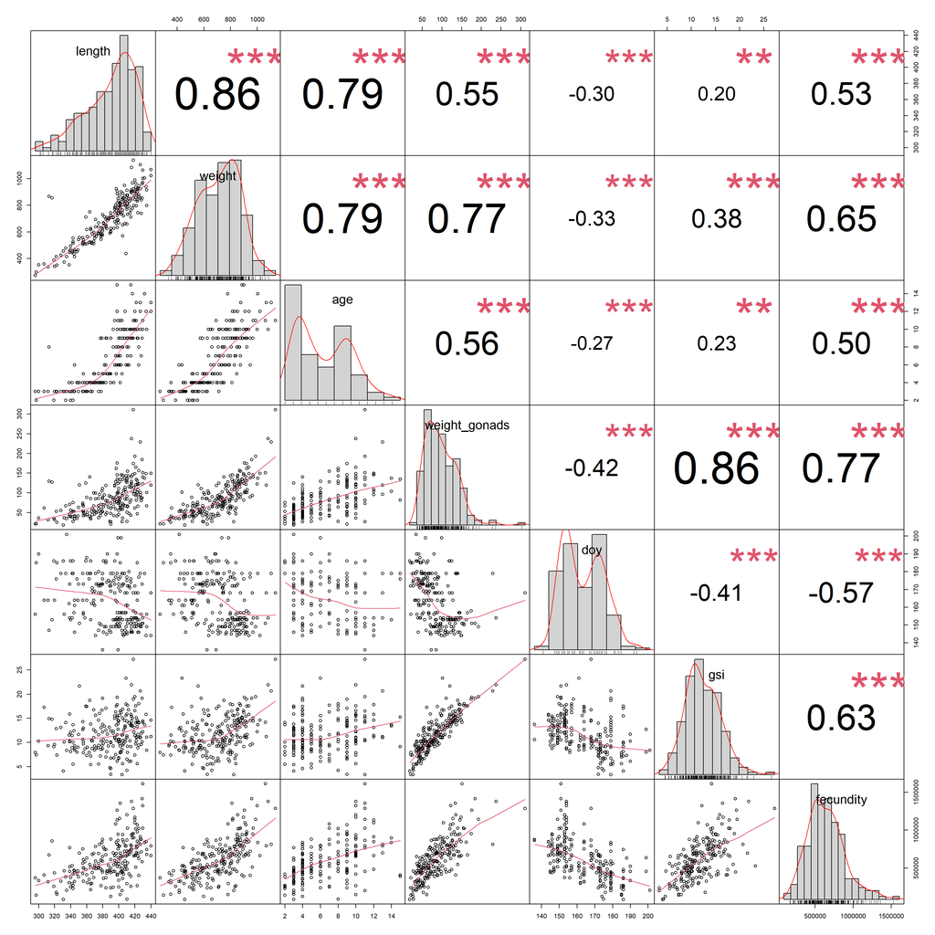

```r
d <- pel[,c('length','weight','age','weight_gonads','doy','gsi','fecundity')]
suppressWarnings(chart.Correlation(d, histogram = TRUE, method = "pearson"))
```

### 3.1.4 pairs (log)

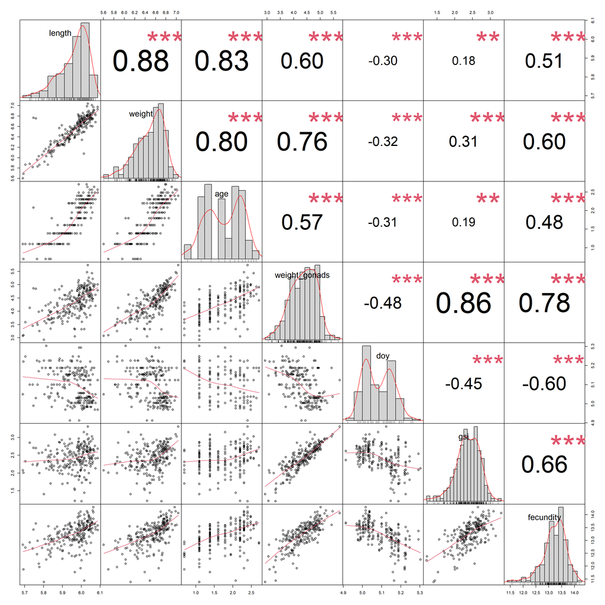

```r
suppressWarnings(chart.Correlation(log(d), histogram = TRUE, method = "pearson"))
```

## 3.2 Linear models

Replicate Pelletier analyses. Pelletier found gonad weight to be the one with the highest predictive power.

```r
# original analyses by Pelletier 1986
models <- ddply(pelm,c('variable'),function(x){
    m <- lm(log10(fecundity)~log10(value),data=x)
    c(variable=unique(as.character(x$variable)),
      intercept=round(unname(coef(m)[1]),2),
      slope=round(unname(coef(m)[2]),2),
      R2=round(summary(m)$r.squared,2),
      R2.adj=round(summary(m)$r.squared,2),
      sigma=round(summary(m)$sigma,2),
      n=nrow(x[!is.na(x$value),]))
})

kable(models[order(models$R2,decreasing = T),])
```

|  | variable | intercept | slope | R2 | R2.adj | sigma | n |
| --- | --- | --- | --- | --- | --- | --- | --- |
| 4 | weight_gonads | 4.34 | 0.75 | 0.61 | 0.61 | 0.13 | 221 |
| 6 | gsi | 4.77 | 0.93 | 0.44 | 0.44 | 0.16 | 221 |
| 2 | weight | 2.75 | 1.06 | 0.36 | 0.36 | 0.17 | 222 |
| 5 | doy | 13.45 | -3.48 | 0.36 | 0.36 | 0.17 | 222 |
| 1 | length | -1.84 | 2.93 | 0.26 | 0.26 | 0.18 | 222 |
| 3 | age | 5.38 | 0.46 | 0.23 | 0.23 | 0.19 | 193 |

## 3.3 Outlier removal

```r
# age
pelo <- pel[pel$age!=15 & !is.na(pel$age),]

# gonad weight
quantile(bio[bio$matur==5 & !is.na(bio$matur) & !is.na(bio$wgonad),'wgonad']*1000,c(0.005,0.995))
```

```
##     0.5%    99.5%
##  15.9489 181.9267
```

```r
pelo <- pelo[pelo$weight_gonads<200,] # weights above 200g are unrealistic

nrow(pelo)
```

```
## [1] 188
```

## 3.4 New model

### 3.4.1 Fit

Gonad weight and age are correlated, and therefore fecundity is predicted in function of age + GSI. Mathieu Boudreau tested a range of models. See script in depricated folder. Here I only retained the selected one to use for model input. Selected robust regression because less weight to lower fecundity values (individuals for which spawning might have started already).

```r
this.m <- robust::lmRob(log(fecundity) ~ log(gsi) + log(ageplus), data = pelo)

car::vif(this.m) # very low
```

```
##     log(gsi) log(ageplus)
##     1.022523     1.022523
```

### 3.4.2 Model info

#### 3.4.2.1 Summary

```r
summary(this.m)
```

```
##
## Call:
## robust::lmRob(formula = log(fecundity) ~ log(gsi) + log(ageplus),
##     data = pelo)
##
## Residuals:
##      Min       1Q   Median       3Q      Max
## -1.31019 -0.20982  0.02055  0.18519  0.68402
##
## Coefficients:
##              Estimate Std. Error t value Pr(>|t|)
## (Intercept)  10.80225    0.21618  49.969  < 2e-16 ***
## log(gsi)      0.71380    0.08521   8.377 1.36e-14 ***
## log(ageplus)  0.41388    0.05663   7.308 8.00e-12 ***
## ---
## Signif. codes:  0 '***' 0.001 '**' 0.01 '*' 0.05 '.' 0.1 ' ' 1
##
## Residual standard error: 0.2842 on 184 degrees of freedom
## Multiple R-Squared: 0.4176
##
## Test for Bias:
##             statistic  p-value
## M-estimate      7.026 0.071064
## LS-estimate    15.124 0.001713
## 1 observation deleted due to missingness
```

#### 3.4.2.2 Validation 1

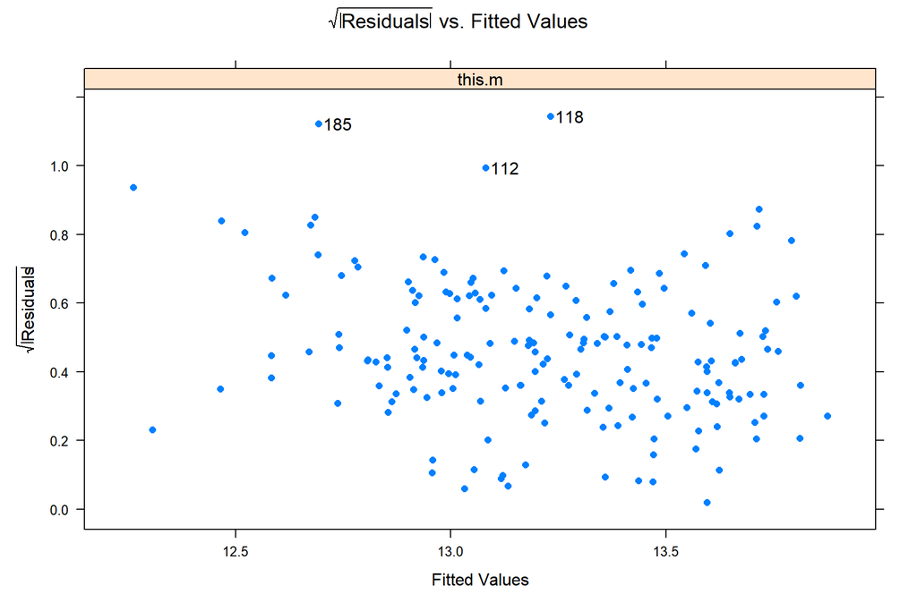

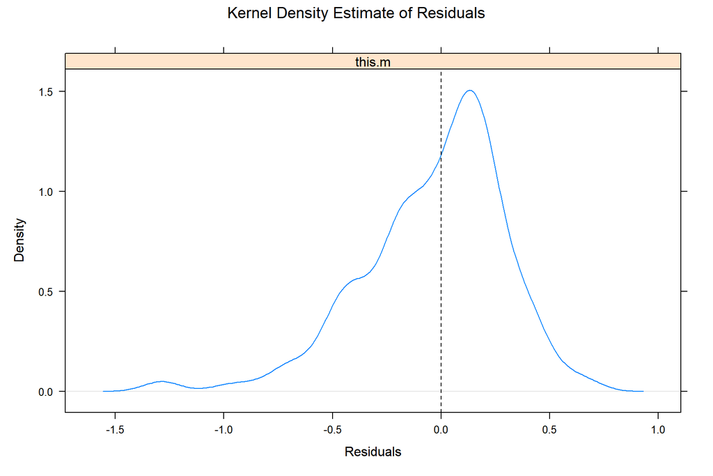

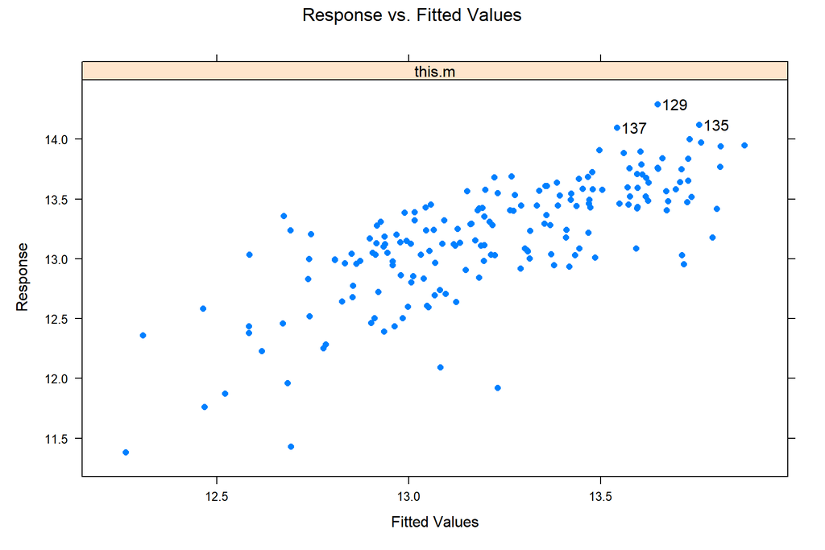

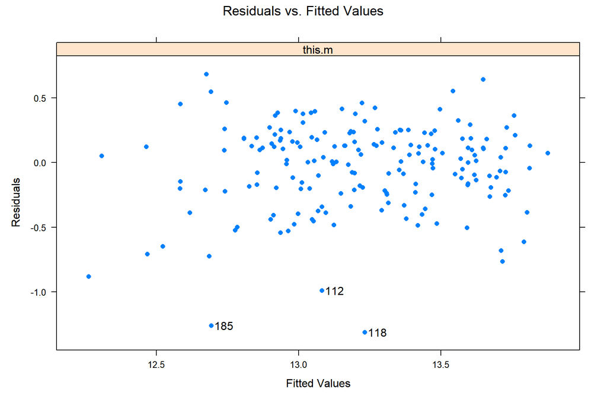

```r
par(mfrow=c(2,2))
plot(this.m,ask = FALSE)
```

#### 3.4.2.3 Validation 2

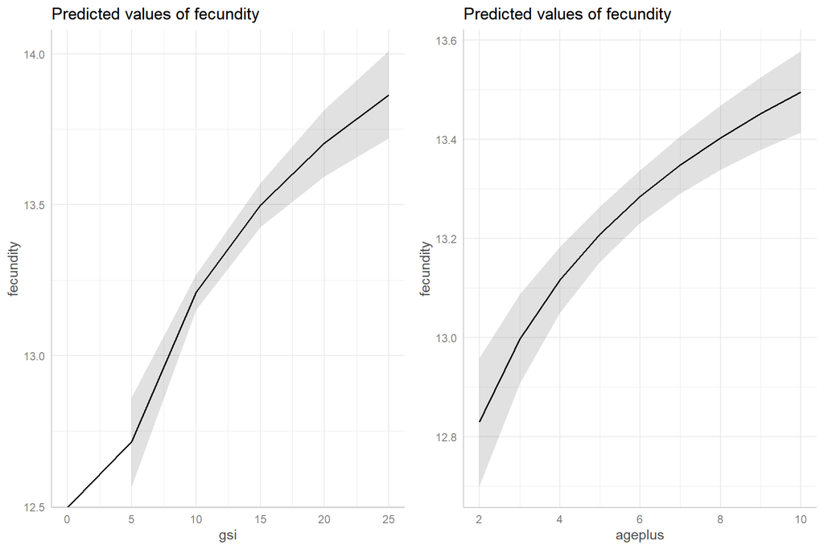

```r
p <-ggeffects::ggeffect(this.m)
grid.arrange(plot(p[[1]]),plot(p[[2]]),nrow=1)
```

# 4 Bio data

## 4.1 Outlier removal

```r
nrow(bio.faa)
```

```
## [1] 5406
```

```r
# month (no "pre-spawners" after July)
bio.faa <- bio.faa[bio.faa$month <8,]

# remove fish with ages that cannot be trusted, based on their length (see 3.0_caa))
bio.faa <- bio.faa[bio.faa$age<18,]
bio.faa <- ddply(bio.faa,c('age'),transform,outlierAL=outlier(length,coef=3))
bio.faa[is.na(bio.faa$outlierAL),'outlierAL'] <- FALSE

# incorrect weights
bio.faa <- bio.faa[bio.faa$weight>0,]

lw <- lm(log(bio.faa$weight)~log(bio.faa$length))
bio.faa[!is.na(bio.faa$length),'outlierLW'] <- abs(residuals(lw))>sd(residuals(lw))*3
bio.faa[is.na(bio.faa$outlierLW),'outlierLW'] <- FALSE

# gsi
bio.faa <- bio.faa[bio.faa$gsi<33,] # one with gsi =35% (more than one third of this fish is gonad...)
bio.faa <- bio.faa[bio.faa$gsi>3.4,]  # smaller than ever observed for age 2. presumably wrong maturity stage
```

## 4.2 Plots for outliers

### 4.2.1 outliers AL

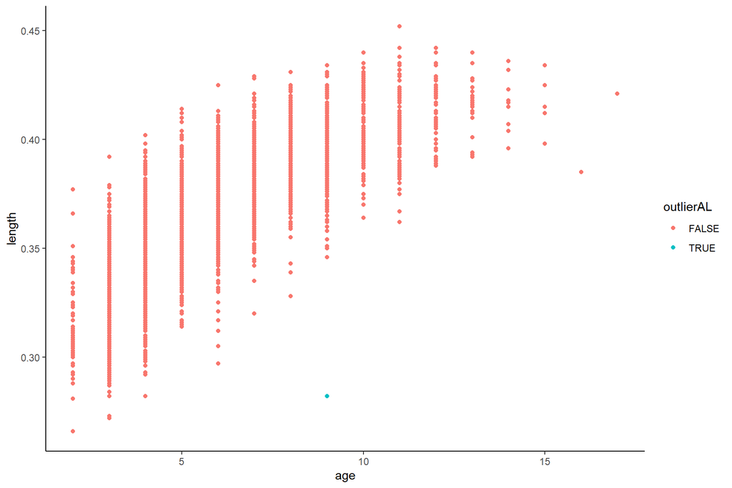

```r
ggplot(bio.faa,aes(x=age,y=length,col=outlierAL))+geom_point()
```

```r
bio.faa <- bio.faa[!bio.faa$outlierAL,]
bio.faa$outlierAL <- NULL
```

### 4.2.2 outliers LW

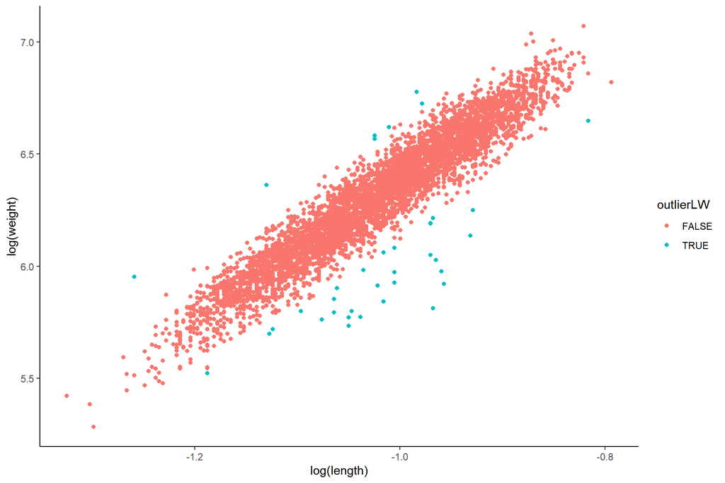

```r
ggplot(bio.faa,aes(x=log(length),y=log(weight),col=outlierLW))+geom_point()
```

```r
bio.faa <- bio.faa[!bio.faa$outlierLW,]
bio.faa$outlierLW <- NULL
```

### 4.2.3 outliers GSI

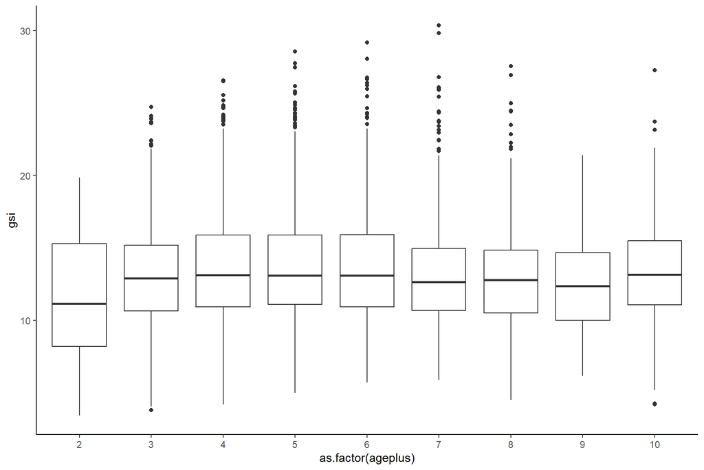

```r
ggplot(bio.faa,aes(x=as.factor(ageplus),y=gsi))+geom_boxplot()
```

## 4.3 Comparison Pelletier

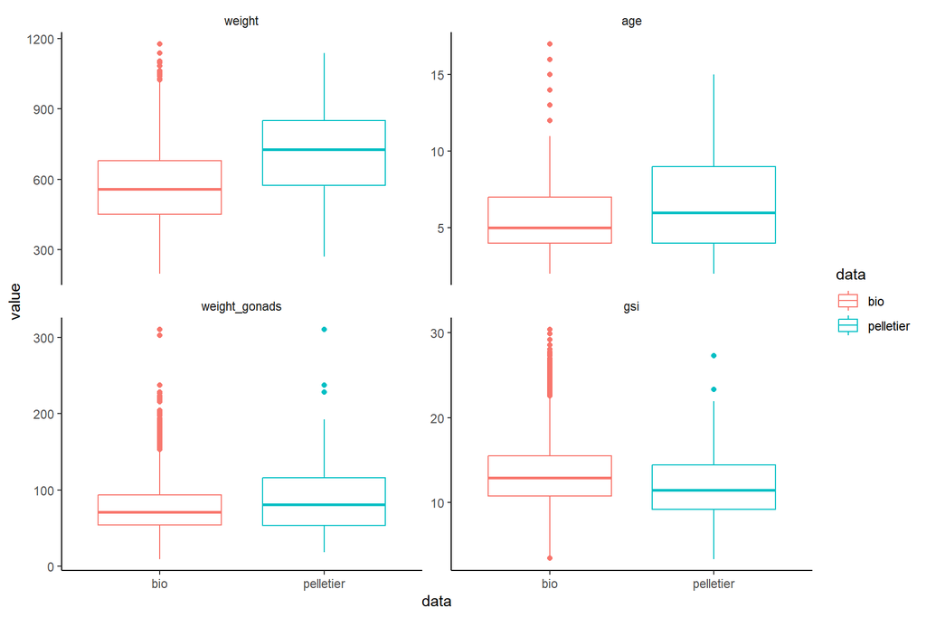

```r
names(bio.faa)[which(names(bio.faa)=='wgonad')] <- 'weight_gonads'
bio.faa$data <- 'bio'
pel$data <- 'pelletier'
cols <- c('weight','age','weight_gonads','gsi','data')
comb <- rbind(bio.faa[,cols],pel[,cols])
comb$id <- 1:nrow(comb)

combm <- melt(comb,id=c('id','data'))
ggplot(combm,aes(x=data,y=value,col=data))+geom_boxplot()+facet_wrap(~variable,scale='free_y')
```

## 4.4 Which months to include?

There is a clear relationship between fecundity and doy. Cannot add variable in model (correlated with gsi). If there are more samples from early on, might result in overestimate of fecundity.

Kept july samples (no correct for doy either) because they are rare and have negligible impact.

### 4.4.1 Plots

#### 4.4.1.1 gsi vs month

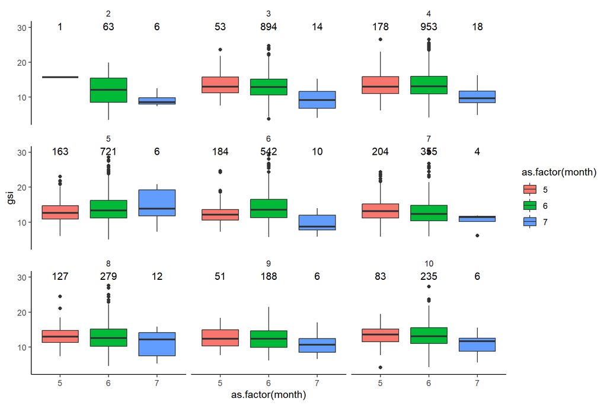

```r
n <- ddply(bio.faa,c('ageplus','month'),summarise,n=length(year))
ggplot(bio.faa,aes(x=as.factor(month),y=gsi))+
    geom_boxplot(aes(fill=as.factor(month)))+
    geom_text(data=n,aes(y=Inf,label=n),vjust=1.1)+
    facet_wrap(~ageplus)
```

#### 4.4.1.2 sample date over time

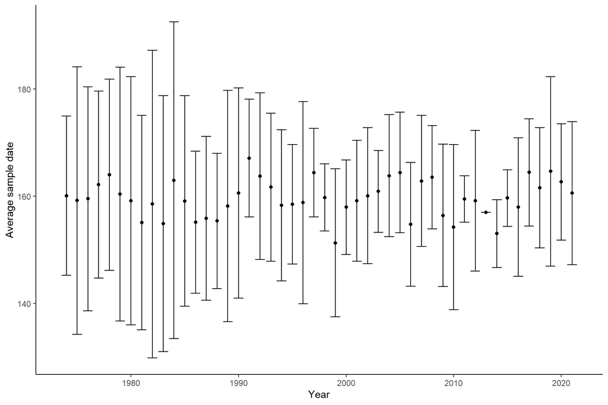

```r
dates <- ddply(bio.faa,c('year'),summarise,mu=mean(doy),low=mu-2*sd(doy),high=mu+2*sd(doy))
ggplot(dates,aes(x=year,y=mu))+geom_point()+geom_errorbar(aes(ymin=low,ymax=high))+
    labs(y='Average sample date',x='Year')
```

# 5 Predictions

## 5.1 Predict

See script test prediction to help understand the approach taken here. se is only used to help weigh the smoothing (but is relative because various shrinkage factors can be used).

```r
faa <- ddply(bio.faa,c('year','ageplus'),summarise,n=length(gsi),gsi.sd=sd(gsi),gsi=mean(gsi))

faa$fec <- exp(predict(this.m,faa))
faa[!is.na(faa$gsi.sd),'fec.se'] <- exp(predict(this.m,data.frame(ageplus=faa$ageplus,gsi=faa$gsi.sd)))
faa[!is.na(faa$gsi.sd),'low'] <- exp(predict(this.m,data.frame(ageplus=faa$ageplus,gsi=pmax(faa$gsi-2*faa$gsi.sd,0.1))))
faa[!is.na(faa$gsi.sd),'high'] <- exp(predict(this.m,data.frame(ageplus=faa$ageplus,gsi=pmax(faa$gsi+2*faa$gsi.sd,0.1))))

minf <- 5 # number of fish should be higher than this
```

## 5.2 Plots

### 5.2.1 FAA raw

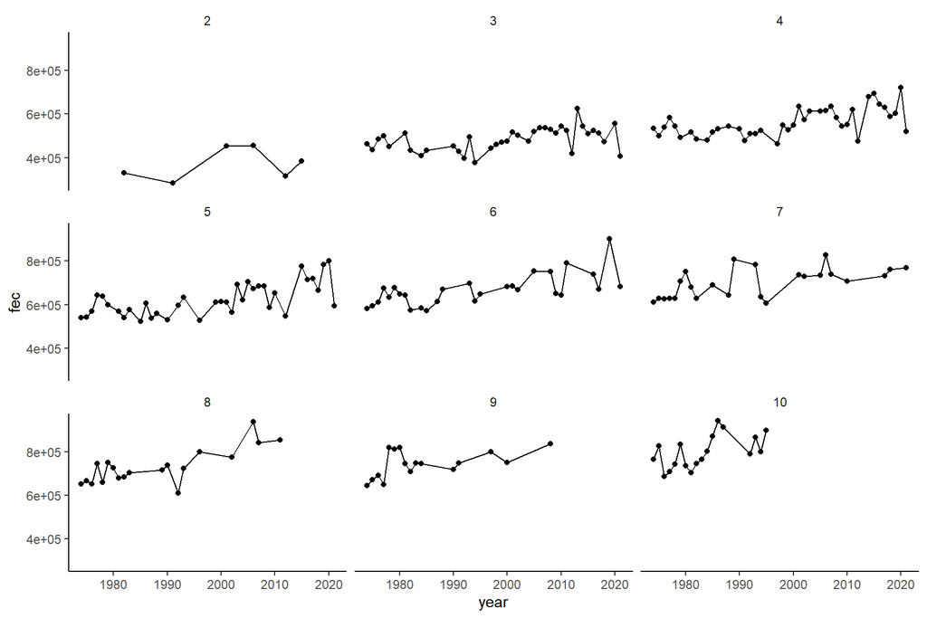

```r
ggplot(faa[faa$n>=minf,],aes(x=year,y=fec))+
    geom_point()+
    geom_line()+
    facet_wrap(~ageplus)
```

### 5.2.2 FAA vs pelletier

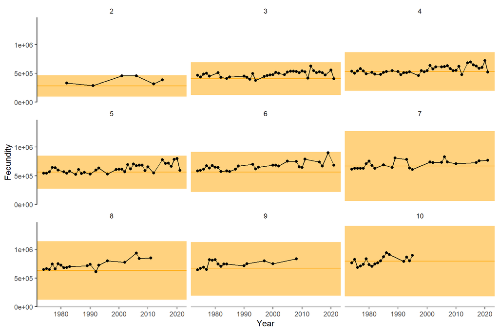

```r
pelfaa <- ddply(pelo[!is.na(pelo$ageplus),],c('ageplus'),summarise,fec=mean(fecundity),fec.se=sd(fecundity))
ggplot(faa[faa$n>=minf,])+
    geom_rect(data=pelfaa,aes(ymin=fec-2*fec.se,ymax=fec+2*fec.se,xmin=-Inf,xmax=Inf),fill='orange',alpha=0.5)+
    geom_hline(data=pelfaa,aes(yintercept=fec),col='orange')+
    geom_point(aes(x=year,y=fec))+
    geom_line(aes(x=year,y=fec))+
    facet_wrap(~ageplus)+
    labs(y='Fecundity',x='Year')
```

### 5.2.3 predicted fec-gsi

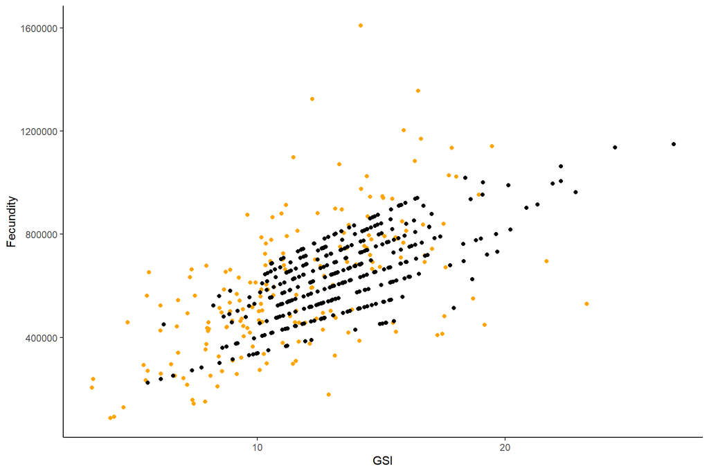

```r
ggplot(faa,aes(x=gsi,y=fec))+
    geom_point(data=pelo,aes(y=fecundity),col='orange')+
    geom_point()+
    labs(y='Fecundity',x='GSI')
```

### 5.2.4 predicted fec-age

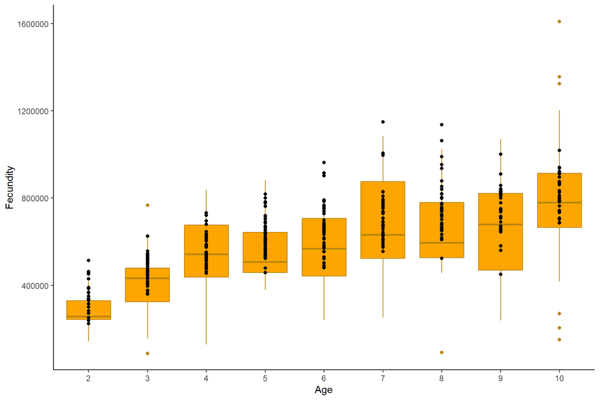

```r
ggplot(faa,aes(x=as.factor(ageplus),y=fec))+
    geom_boxplot(data=pelo[!is.na(pelo$ageplus),],aes(y=fecundity,group=ageplus),fill='orange',col='darkgoldenrod')+
    geom_point()+
    labs(y='Fecundity',x='Age')
```

### 5.2.5 n

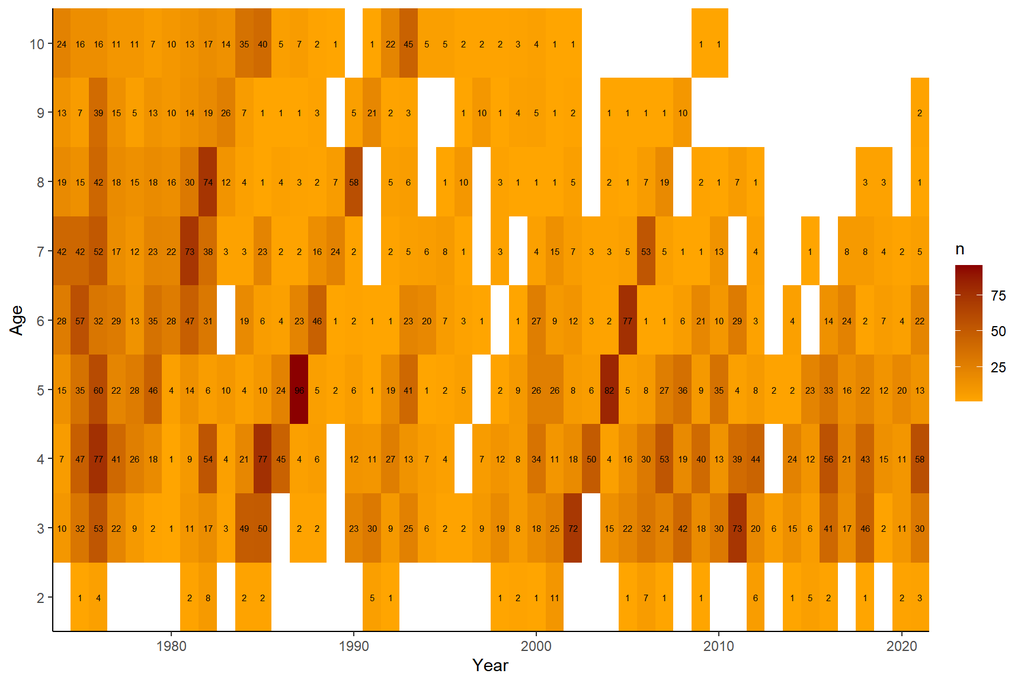

```r
ggplot(faa,aes(x=year,y=as.factor(ageplus)))+
    geom_tile(aes(fill=n))+
    geom_text(aes(label = n), size = 2)+
    scale_fill_gradient(low = "orange", high = "darkred") +
    labs(y='Age',x='Year')+
    scale_x_continuous(expand = c(0,0))+
    scale_y_discrete(expand=c(0,0))
```

### 5.2.6 GSI

Check underlying trend

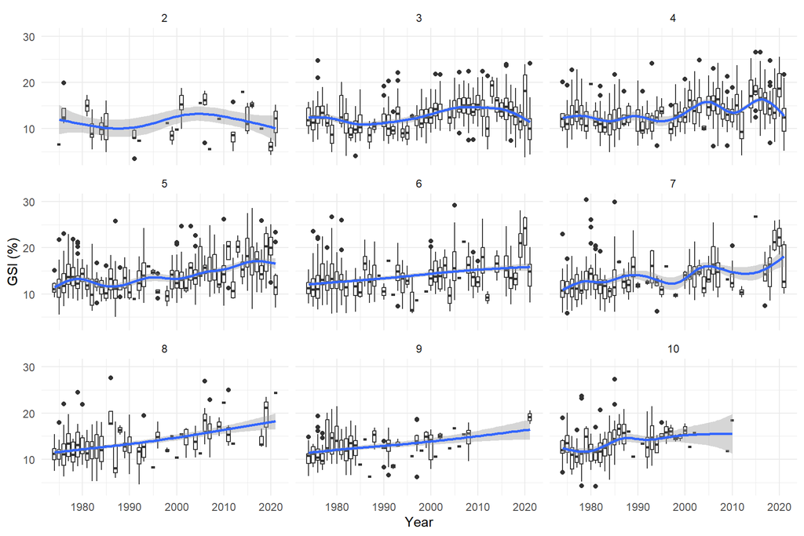

```r
ggplot(bio.faa,aes(x=year,y=gsi))+
    geom_boxplot(aes(group=year))+
    geom_smooth()+
    facet_wrap(~ageplus)+
    labs(x='Year',y='GSI (%)')+
    theme_minimal()
## `geom_smooth()` using method = 'gam' and formula = 'y ~ s(x, bs = "cs")'
```

# 6 Fill and smooth

## 6.1 fit model

```r
faam <- faa[faa$n>=minf,]
faam$cv <- with(faam,fec.se/fec)
names(faam)[which(names(faam)=='ageplus')] <- 'age'

all <- expand.grid(year=1968:this.year, age=min(faam$age):max(faam$age))
faam <- merge(all, faam, all.x = TRUE)

faa.fit <- armatrix.fit(year=faam$year,age=faam$age,x=faam$fec,cv=faam$cv,shrink.cv = 0.5)  # shrink reduces cv variability, not overall uncertainty
faa.fit  # convergence ok

save(faa.fit,file=paste0("Rdata/fit.armatrix/",this.year,"base_cv1shrink0.5.Rdata"))
#save(faa.fit,file=paste0("Rdata/fit.armatrix/",this.year,"base_cv4shrink0.5.Rdata"))
```

[output not shown]

## 6.2 plots

### 6.2.1 waa

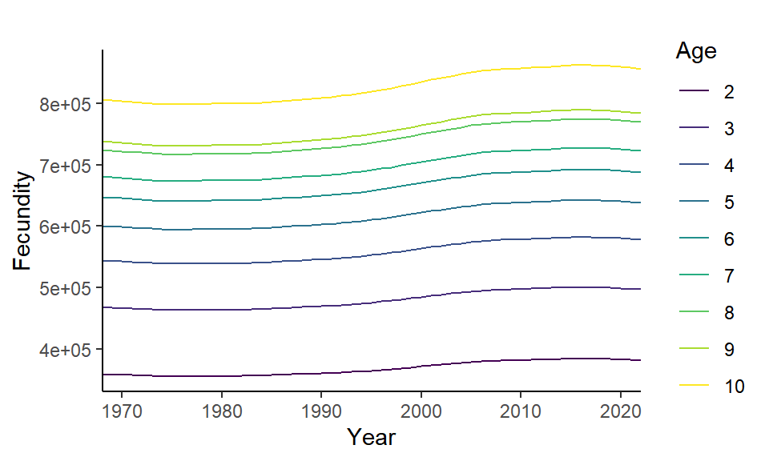

```r
armatrix.waa(faa.fit,ylab='Fecundity')+scale_color_viridis_d()
```

### 6.2.2 Predicted obs

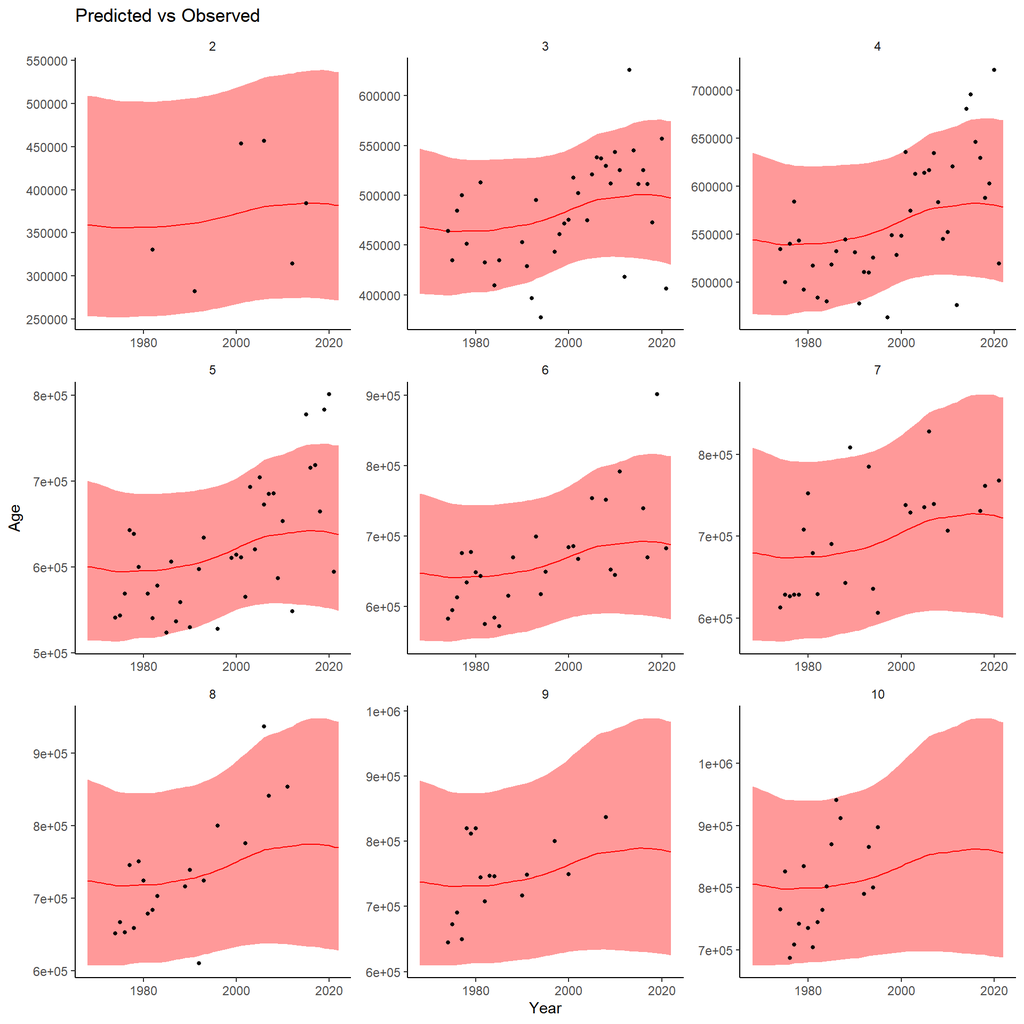

```r
armatrix.predobs(faa.fit,scale='free',ncol=3)
```

### 6.2.3 Predicted

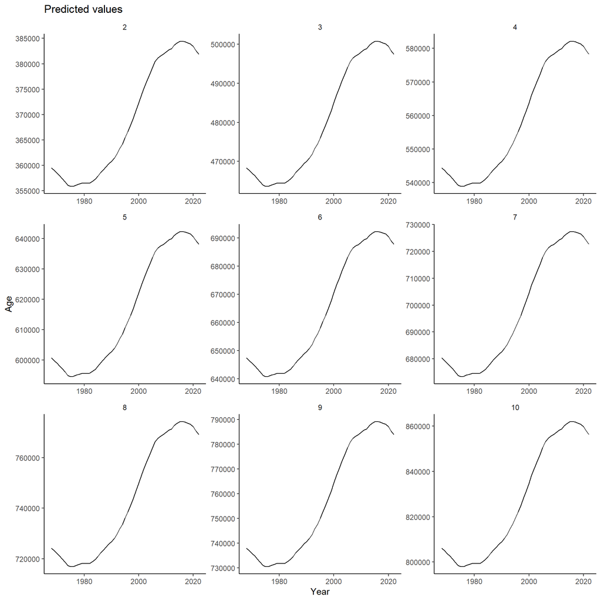

```r
armatrix.pred(faa.fit,scale='free',ncol=3)
```

### 6.2.4 Resid bubble

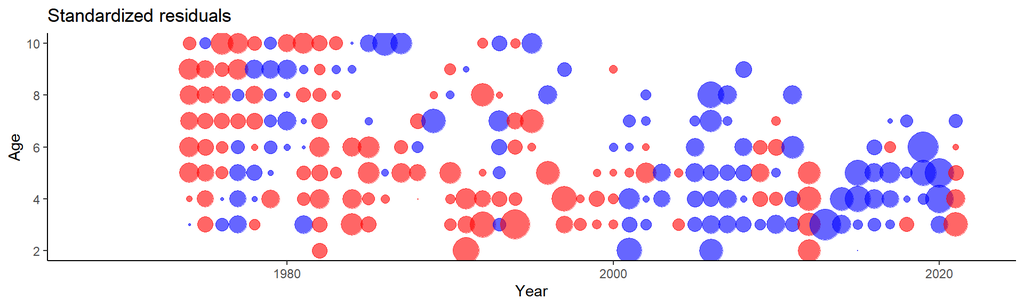

```r
armatrix.res(faa.fit)
```

### 6.2.5 Resid dot

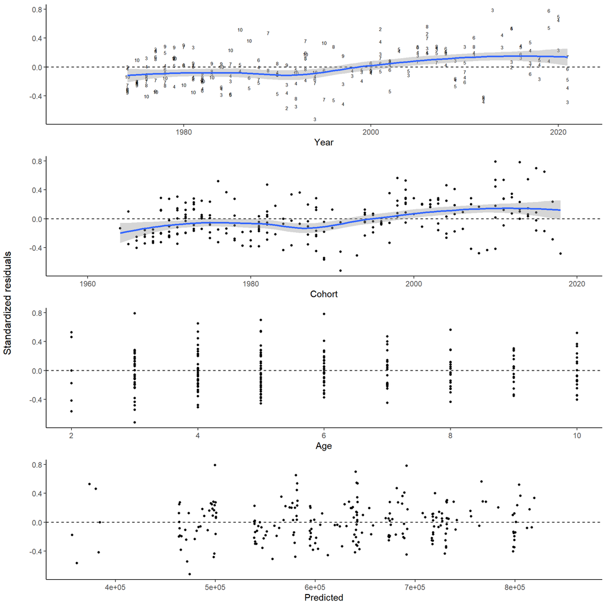

```r
armatrix.res2(faa.fit)
```

### 6.2.6 effects

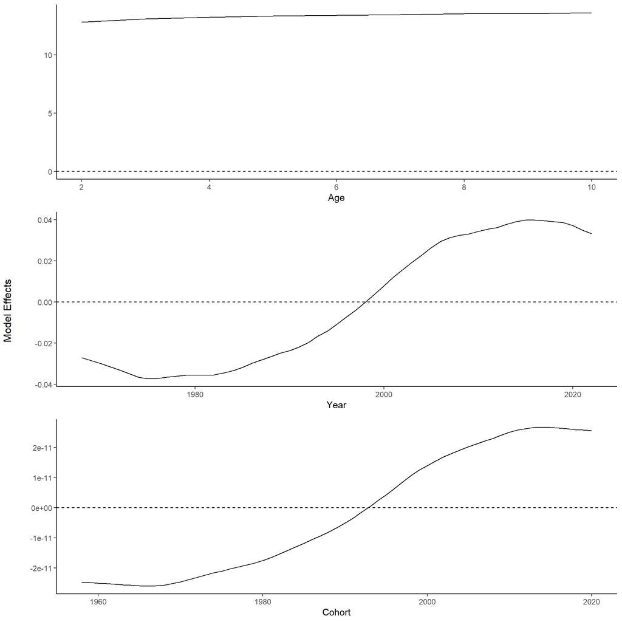

```r
armatrix.effects(faa.fit)
```

### 6.2.7 cvs

Only interesting if shrink argument is used.

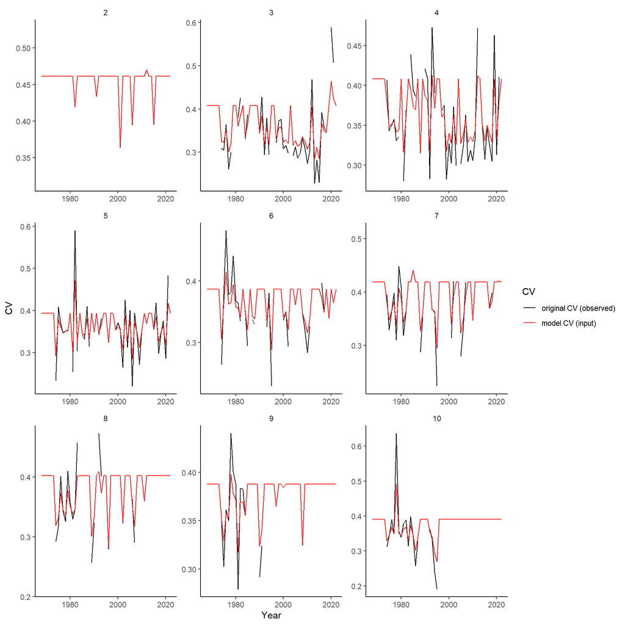

```r
armatrix.cvs(faa.fit,scale='free',ncol=3)
```

# 7 Save results

Predict fecundity age 1 fish based on the predicted ratio of fecundity age 2 / age 1 from pelletier

```r
faaf <- faa.fit$output
faaf <- faaf[,c(1:2,9)]
names(faaf)[3] <- 'fecundity'
faafm <- dcast(faaf,year~age,value.var = 'fecundity')

# add age 1
m <-  as.numeric(models[models$variable=='age',-1])
fec1fec2 <- (10^(m[1]+log10(1)*m[2]))/(10^(m[1]+log10(2)*m[2]))
fec1fec2
```

```
## [1] 0.7269863
```

```r
faafm <- cbind(year=faafm$year,'1'=faaf[faaf$age==2,'fecundity']*fec1fec2,faafm[,2:ncol(faafm)])
faafm[,2:ncol(faafm)] <- round(faafm[,2:ncol(faafm)],0)

write.csv(faafm, file=paste0('csv/faa_',this.year,'_base_cv1shrink0.5.csv'),row.names = FALSE)
#write.csv(faafm, file=paste0('csv/faa_',this.year,'_sens_cv4shrink0.5.csv'))

p <- ggplot(melt(faafm,id='year'), aes(x = year, y = value/1000, col = variable))+
    geom_line()+
    labs(x = 'Year', y = 'Fecundity (thousands)', col = 'Age')+
    scale_x_continuous(expand = c(0, 0))+
    scale_color_viridis_d()
ggsave(filename = paste0('img/faa',this.year,'.png'),plot = p,units = 'cm',height = 8,width = 14)
```